# Lasso panalty tuning with Tidymodels

# 3 EDA with visualization (탐색적 데이터 분석)

## 3.1 Distribution of `sale_price`

If we check out the distribution of the house price, it is little bit skewed to the right.

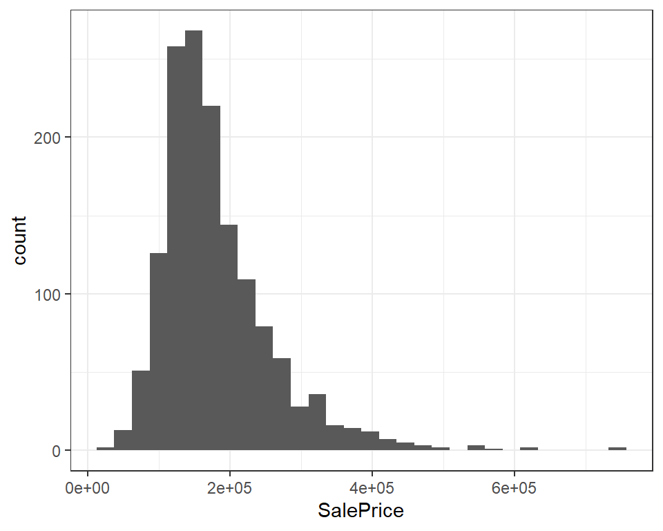

```r
train %>%
  ggplot(aes(x = SalePrice)) +
  geom_histogram()
```

Since we want to build a linear regression assume that the noise follows the normal distribution, let us take a log to `SalePrice` variable.

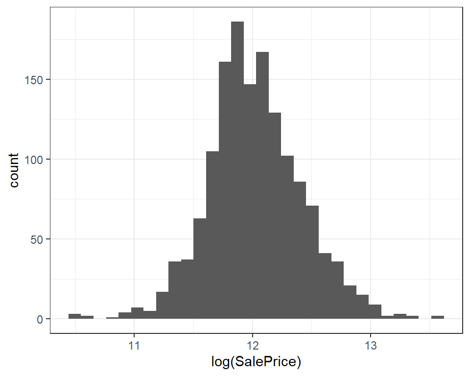

```r
train %>%
  ggplot(aes(x = log(SalePrice))) +
  geom_histogram()
```

## 3.2 `NA`s

There is a nice package for checking out `NA`s. Let’s see how many variables we have which contains `NA`s.

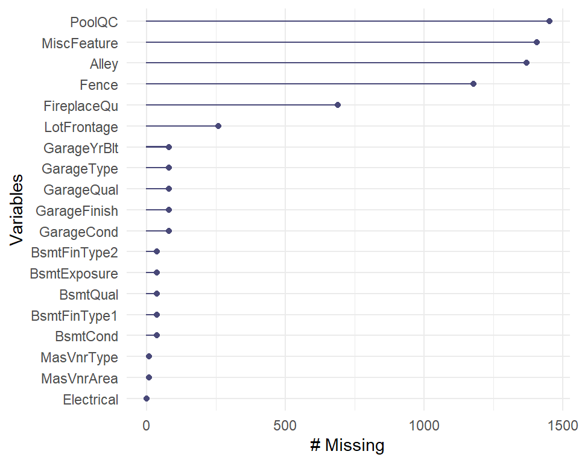

```r
library(naniar)
train %>%
  # select_if(~sum(is.na(.)) > 0) %>% # alternative way
  select(where(~sum(is.na(.)) > 0)) %>%
  gg_miss_var()
```

We can do more analysis about `NA`s with `upset()` function, which shows that most of the observations with `NA`s in the data set have `NA`s at the `PoolQC`, `MiscFeature`, `Alley`, `Fence` at the same time.

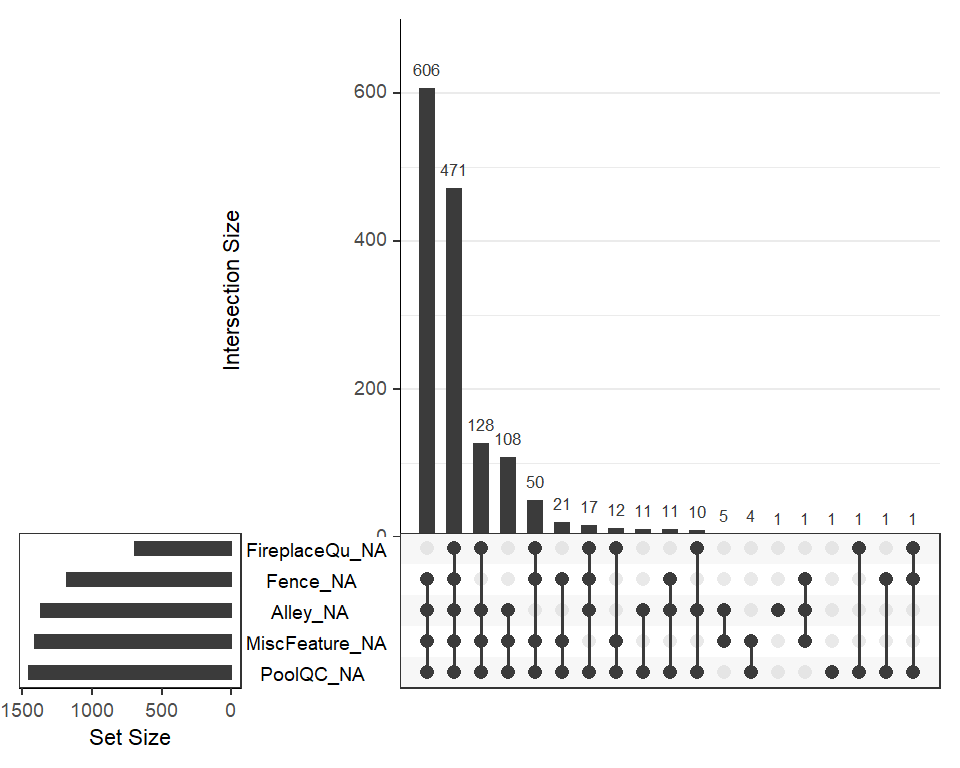

```r
train %>%
  select(where(~sum(is.na(.)) > 0)) %>%
  gg_miss_upset()
```

# 4 Preprecessing with `recipe` (전처리 레시피 만들기)

First, I would like to clean the variable names with `janitor` package so that we have consistent varible names.

## 4.1 `all_data` combine and name cleaning with `janitor`

```r
all_data <- bind_rows(train, test) %>%
  janitor::clean_names()
names(all_data)[1:10]
```

```
##  [1] "id"           "ms_sub_class" "ms_zoning"    "lot_frontage" "lot_area"
##  [6] "street"       "alley"        "lot_shape"    "land_contour" "utilities"
```

## 4.2 Make recipe

Note that we will use mode imputation for nominal variables for the baseline, and the mean imputation for the numerical variables. However, this should be changed to build a more sensitive model because we have checked that the `NA` in the nominal variables indicates that cases where the house doesn’t have the corresponding attributes.

```r
housing_recipe <- all_data %>%
  recipe(sale_price ~ .) %>%
  step_rm(id) %>%
  step_log(sale_price) %>%
  step_modeimpute(all_nominal()) %>%
  step_dummy(all_nominal()) %>%
  step_meanimpute(all_predictors()) %>%
  step_normalize(all_predictors()) %>%
  prep(training = all_data)

print(housing_recipe)
```

```
## Data Recipe
##
## Inputs:
##
##       role #variables
##    outcome          1
##  predictor         80
##
## Training data contained 2919 data points and 2919 incomplete rows.
##
## Operations:
##
## Variables removed id [trained]
## Log transformation on sale_price [trained]
## Mode Imputation for ms_zoning, street, alley, ... [trained]
## Dummy variables from ms_zoning, street, alley, lot_shape, ... [trained]
## Mean Imputation for ms_sub_class, lot_frontage, ... [trained]
## Centering and scaling for ms_sub_class, lot_frontage, ... [trained]
```

## 4.3 `juice` the all_data2 and split

```r
all_data2 <- juice(housing_recipe)
```

We are done for preprocessing. Let’s split the data set.

```r
train_index <- seq_len(nrow(train))
train2 <- all_data2[train_index,]
test2 <- all_data2[-train_index,]
```

```r
train2 %>%
  head() %>%
  kable()
```

| ms_sub_class | lot_frontage | lot_area | overall_qual | overall_cond | year_built | year_remod_add | mas_vnr_area | bsmt_fin_sf1 | bsmt_fin_sf2 | bsmt_unf_sf | total_bsmt_sf | x1st_flr_sf | x2nd_flr_sf | low_qual_fin_sf | gr_liv_area | bsmt_full_bath | bsmt_half_bath | full_bath | half_bath | bedroom_abv_gr | kitchen_abv_gr | tot_rms_abv_grd | fireplaces | garage_yr_blt | garage_cars | garage_area | wood_deck_sf | open_porch_sf | enclosed_porch | … |
| --- | --- | --- | --- | --- | --- | --- | --- | --- | --- | --- | --- | --- | --- | --- | --- | --- | --- | --- | --- | --- | --- | --- | --- | --- | --- | --- | --- | --- | --- | --- |
| 0.0673199 | -0.2020329 | -0.2178414 | 0.6460727 | -0.5071973 | 1.0460784 | 0.8966793 | 0.5251119 | 0.5808073 | -0.2930798 | -0.9347024 | -0.4442517 | -0.7737285 | 1.2071717 | -0.1011797 | 0.4134764 | 1.0868363 | -0.2498524 | 0.781232 | 1.2323877 | 0.169898 | -0.2076629 | 0.9866803 | -0.9241529 | 1.0007573 | 0.3064753 | 0.3488399 | -0.7406335 | 0.1999717 | -0.3595391 | … |
| -0.8734664 | 0.5017845 | -0.0720317 | -0.0631737 | 2.1879039 | 0.1547375 | -0.3955364 | -0.5721522 | 1.1779104 | -0.2930798 | -0.6297885 | 0.4770294 | 0.2610301 | -0.7848906 | -0.1011797 | -0.4718098 | -0.8195386 | 3.8217640 | 0.781232 | -0.7561915 | 0.169898 | -0.2076629 | -0.2877090 | 0.6235248 | -0.0849858 | 0.3064753 | -0.0597822 | 1.6146027 | -0.7027224 | -0.3595391 | … |
| 0.0673199 | -0.0612694 | 0.1371734 | 0.6460727 | -0.5071973 | 0.9800531 | 0.8488195 | 0.3347702 | 0.0978563 | -0.2930798 | -0.2884670 | -0.2990251 | -0.6106138 | 1.2351632 | -0.1011797 | 0.5636589 | 1.0868363 | -0.2498524 | 0.781232 | 1.2323877 | 0.169898 | -0.2076629 | -0.2877090 | 0.6235248 | 0.9203319 | 0.3064753 | 0.6274459 | -0.7406335 | -0.0811953 | -0.3595391 | … |
| 0.3025164 | -0.4366387 | -0.0783713 | 0.6460727 | -0.5071973 | -1.8590326 | -0.6826955 | -0.5721522 | -0.4948563 | -0.2930798 | -0.0472664 | -0.6711682 | -0.5061185 | 0.9785744 | -0.1011797 | 0.4273090 | 1.0868363 | -0.2498524 | -1.027187 | -0.7561915 | 0.169898 | -0.2076629 | 0.3494857 | 0.6235248 | 0.7996938 | 1.6196836 | 0.7853226 | -0.7406335 | -0.1847831 | 3.8743031 | … |
| 0.0673199 | 0.6894691 | 0.5188142 | 1.3553191 | -0.5071973 | 0.9470405 | 0.7530998 | 1.3872480 | 0.4688505 | -0.2930798 | -0.1610403 | 0.2115370 | -0.0371639 | 1.6713642 | -0.1011797 | 1.3778060 | 1.0868363 | -0.2498524 | 0.781232 | 1.2323877 | 1.385418 | -0.2076629 | 1.6238750 | 0.6235248 | 0.8801192 | 1.6196836 | 1.6861486 | 0.7768341 | 0.5403318 | -0.3595391 | … |
| -0.1678767 | 0.7363903 | 0.5004295 | -0.7724201 | -0.5071973 | 0.7159521 | 0.5138006 | -0.5721522 | 0.6378834 | -0.2930798 | -1.1303934 | -0.5804016 | -0.9266484 | 0.5353755 | -0.1011797 | -0.2742013 | 1.0868363 | -0.2498524 | -1.027187 | 1.2323877 | -2.261142 | -0.2076629 | -0.9249036 | -0.9241529 | 0.5986302 | 0.3064753 | 0.0330864 | -0.4244944 | -0.2587744 | -0.3595391 | … |

# 5 Split the train into two

We will devide `train2` into two sets: model training part and assessment part. To evaluate the models with a specific panalty parameter, we need to split the `train2` again; we cannot use test set, right? :)

```r
set.seed(2021)

validation_split <- validation_split(train2, prop = 0.7)

# actual split id stored in the following
# validation_split$splits[[1]]$in_id
# the whole point is that it's there and trust tidymodels :)
head(validation_split$splits[[1]]$in_id)
```

```
## [1]  903  166 1454  442  743  908
```

The key part is that, we will choose the panalty that performs well on the `validation_set`.

# 6 Set the tuning spec

```r
tune_spec <- linear_reg(penalty = tune(), mixture = 0) %>%
  set_engine("glmnet")

lambda_grid <- grid_regular(penalty(), levels = 50)
```

# 7 Set workflow()

```r
workflow <- workflow() %>%
  add_model(tune_spec) %>%
  add_formula(sale_price ~ .)
```

# 8 Tuning the lambda

```r
doParallel::registerDoParallel()

tune_result <- workflow %>%
  tune_grid(validation_split,
            grid = lambda_grid,
            metrics = metric_set(rmse))
```

```r
tune_result %>%
  collect_metrics()
```

```
## # A tibble: 50 x 7
##     penalty .metric .estimator  mean     n std_err .config
##       <dbl> <chr>   <chr>      <dbl> <int>   <dbl> <chr>
##  1 1.00e-10 rmse    standard   0.137     1      NA Preprocessor1_Model01
##  2 1.60e-10 rmse    standard   0.137     1      NA Preprocessor1_Model02
##  3 2.56e-10 rmse    standard   0.137     1      NA Preprocessor1_Model03
##  4 4.09e-10 rmse    standard   0.137     1      NA Preprocessor1_Model04
##  5 6.55e-10 rmse    standard   0.137     1      NA Preprocessor1_Model05
##  6 1.05e- 9 rmse    standard   0.137     1      NA Preprocessor1_Model06
##  7 1.68e- 9 rmse    standard   0.137     1      NA Preprocessor1_Model07
##  8 2.68e- 9 rmse    standard   0.137     1      NA Preprocessor1_Model08
##  9 4.29e- 9 rmse    standard   0.137     1      NA Preprocessor1_Model09
## 10 6.87e- 9 rmse    standard   0.137     1      NA Preprocessor1_Model10
## # ... with 40 more rows
```

# 9 Visualization of the tunning result

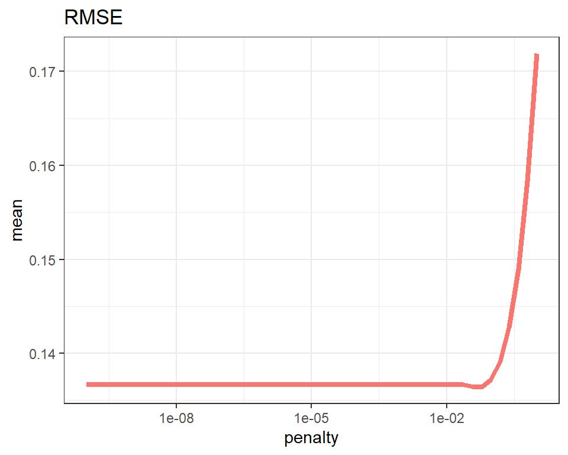

```r
tune_result %>%
  collect_metrics() %>%
  ggplot(aes(penalty, mean, color = .metric)) +
  geom_line(size = 1.5) +
  scale_x_log10() +
  theme(legend.position = "none") +
  labs(title = "RMSE")
```

```r
tune_result %>% show_best()
```

```
## # A tibble: 5 x 7
##    penalty .metric .estimator  mean     n std_err .config
##      <dbl> <chr>   <chr>      <dbl> <int>   <dbl> <chr>
## 1 5.96e- 2 rmse    standard   0.136     1      NA Preprocessor1_Model44
## 2 3.73e- 2 rmse    standard   0.137     1      NA Preprocessor1_Model43
## 3 1.00e-10 rmse    standard   0.137     1      NA Preprocessor1_Model01
## 4 1.60e-10 rmse    standard   0.137     1      NA Preprocessor1_Model02
## 5 2.56e-10 rmse    standard   0.137     1      NA Preprocessor1_Model03
```

```r
tune_best <- tune_result %>% select_best(metric = "rmse")
tune_best$penalty
```

```
## [1] 0.05963623
```

# 10 Set Ridge regression model and fitting (Ridge regeression 모델 설정 및 학습)

```r
lasso_model <-
    linear_reg(penalty = tune_best$penalty, # tuned penalty
               mixture = 0) %>% # lasso: 1, ridge: 0
    set_engine("glmnet")

lasso_fit <-
    lasso_model %>%
    fit(sale_price ~ ., data = train2)

options(max.print = 10)
lasso_fit %>%
    tidy() %>%
    filter(estimate > 0.001)
```

```
## # A tibble: 116 x 3
##    term           estimate penalty
##    <chr>             <dbl>   <dbl>
##  1 (Intercept)    12.0      0.0596
##  2 lot_area        0.0140   0.0596
##  3 overall_qual    0.0579   0.0596
##  4 overall_cond    0.0320   0.0596
##  5 year_built      0.0201   0.0596
##  6 year_remod_add  0.0180   0.0596
##  7 mas_vnr_area    0.00554  0.0596
##  8 bsmt_fin_sf1    0.0103   0.0596
##  9 bsmt_fin_sf2    0.00638  0.0596
## 10 bsmt_unf_sf     0.00477  0.0596
## # ... with 106 more rows
```

# 11 Prediction and submit (예측 및 평가)

```r
result <- predict(lasso_fit, test2)
result %>% head()
```

```
## # A tibble: 6 x 1
##   .pred
##   <dbl>
## 1  11.7
## 2  11.9
## 3  12.1
## 4  12.2
## 5  12.2
## 6  12.0
```

```r
submission <- read_csv(file.path(file_path, "sample_submission.csv"))
submission$SalePrice <- exp(result$.pred)
write.csv(submission, row.names = FALSE,
          "lasso_regression_tuned.csv")
```